# Version Control in git

2022-10-25

## 1. Let me tell you a story…

## Once upon a time…

- Wolfman and Dracula have been hired to plan a Mars mission (obviously)
- Wolfman and Dracula live on different continents
- They work on the same plan at the same time
- How to manage this?
  - take turns on each file?
  - email copies?
- The solution? **Version Control**

## Advantage of version control

- Nothing that is committed is *ever* lost (unless you try…)
- We can record who made which changes, and when
- We can revert to previous versions.
- We can identify and correct conflicts

A lab notebook for computational analyses and code development.

## 2. Version control with `git`

## What lies ahead…?

## Learning objectives

- Understand the basics of automated version control
- Understand the basics of `git`

## Do you recognise this?

(i.e. have you *ever* worked on the same document as someone else?)

[figure not shown]

## How version control works

- Version control is like a ‘recording’ of history

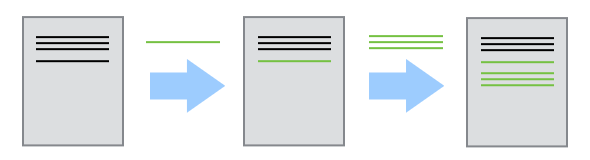

- Rewind and play back changes

## Multiple editors (branching)

- Two people work on a document
  - Each makes independent changes: two versions

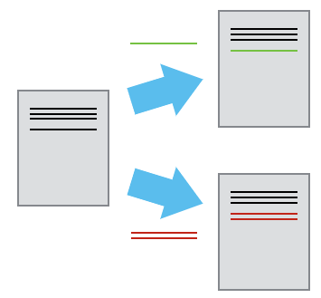

- Changes are separate from the document

## Combining changes (merging)

- Several changes can be merged onto the same base document
  - ‘Merging’

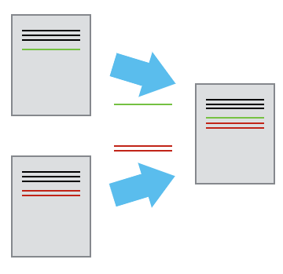

## What version control systems do

- Version control systems manage this process
  - track changes
  - store metadata (who, when)
  - record ‘versions’ (a.k.a. *commits*)
- The complete history of *commits* and metadata is a *repository*
- **CVS, Subversion, RCS**: legacy systems
- **`git`, Mercurial**: modern *distributed* VC tools

## 3. Setting up `git`

## Learning objectives

- Configure `git` for first use on a computer
- Understand `git config --global`

## Setting global options

- `git` needs to know who you are for metadata
- `git` wants your preferences for display/editing

**Live Presentation**

```
git config --global user.name "Vlad Dracul"
git config --global user.email "vlad@tran.sylvan.ia"
git config --global color.ui "auto"
git config --global core.editor "nano -w"
git config --global core.editor \
"'C:\Program Files (x86)\Notepad++\notepad++.exe' \
-multiInst -notabbar -nosession -noPlugin"
```

## 4. Creating a repository

## Learning objectives

- Create a local `git` repository
- What is in a repository?
  - files
  - commits
  - metadata

## Creating a `git` repository

- A fictional project about planets
  - (Wolfman and Dracula…)

**Live Presentation**

```
git init
git status
```

## 5. Tracking changes

## Learning objectives

- Practice the modify-add-commit cycle
- Understand where information is stored, in the `git` workflow

## My first untracked file

- We’ll create a file, but do nothing with it
  - “Is Mars suitable as a space base?”

**Live Presentation**

```
nano mars.txt
```

## My first `git` commit

- We tell `git` that it should *track* a file (watch for changes): `git add`
- We also `git commit` the file (keep a copy of the file in the *repository*, in its current state)

**Live Presentation**

```
git add mars.txt
git commit -m "start notes on Mars as a base"
git log
```

## The staging area

- We don’t always want to commit all changes
- The *staging area* holds changes we want to commit
  - (other files may also be changed, but we don’t want to commit them)

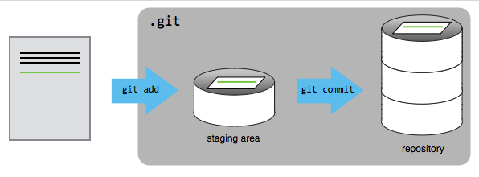

## modify-add-commit

- Now we want to add more information to the file
  - Modify file
  - Add file to *staging area* (`git add`)
  - Commit changes

**Live Presentation**

```
nano mars.txt
git diff
git add mars.txt
git diff
git commit
```

## Question

- Which command(s) below would save changes in `myfile.txt` to the local `git` repository?

```
1. git commit -m "add recent changes"
2. git init myfile.txt; git commit -m "add recent changes"
3. git add myfile.txt; git commit -m "add recent changes"
4. git commit -m myfile.txt "add recent changes"
```

## Challenge 1 (5min)

- Make a one-line change to `mars.txt`.
- Create file `earth.txt` with one-line comment on Earth.
- Commit both changes (*as a **single*** `commit`)

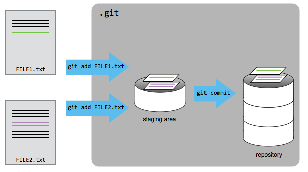

## The modify-add-commit lifecycle

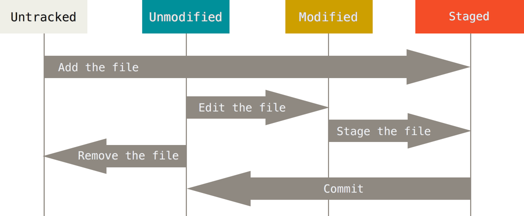

## In which I predict the future…

[figure not shown]

## 6. Exploring history

## Is history bunk?

- How can I identify old versions of files?
- How do I review changes between commits?
- How can I recover old file versions?

## Learning objectives

- Understand what the `HEAD` of a repository is
- Identify and use `git` commit numbers
- Compare various versions of tracked files
- Restore old versions of files

## Commit history

- Most recent commit: `HEAD`
- Next-most recent: `HEAD~1`
- Next-next-most recent: `HEAD~2`

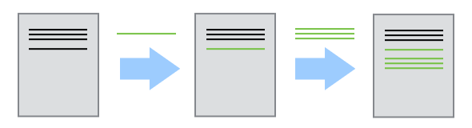

## History with `git diff`

- We can use `git diff` to see what changed for a file at each commit

**Live Presentation**

```
git diff HEAD~1 mars.txt
git diff HEAD~2 mars.txt
```

## History with commit IDs

- We can use the unique ID for a commit in the same way

**Live Presentation**

```
git diff d22195b9ec3c8fb4c2ce0f52f344b95ce5d0d0e3 mars.txt
git diff d221 mars.txt
```

## Restoring older versions

- How can we restore older versions/backtrack?
- Let’s say we accidentally overwrite a file…

**Live Presentation**

```
git checkout HEAD mars.txt
```

## `git checkout`

- `git checkout` “checks out” files from the repo
  - Can use any commit identifier
  - Check out the commit *before* the edit you want to replace!

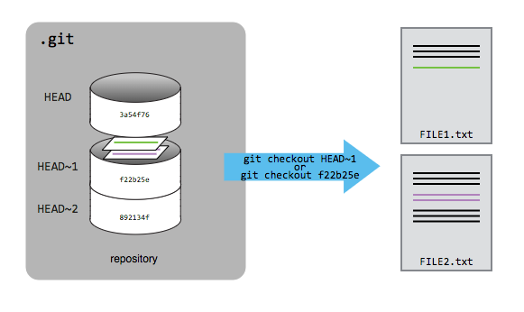

## Question

- Which command(s) below will let Jennifer recover the last committed version of her Python script called `data_cruncher.py` (but no other files)?

```
1. $ git checkout HEAD
2. $ git checkout HEAD data_cruncher.py
3. $ git checkout HEAD~1 data_cruncher.py
4. $ git checkout <unique ID of last commit> data_cruncher.py
```

## 7. Ignoring things

## Learning objectives

- Configure `git` to ignore files and directories
- Understand why this is useful

## Not all files are useful

- Editor backup files
- Temporary files
- Intermediate analysis files

**Live Presentation**

```
mkdir results
touch a.dat results/a.out
```

## .gitignore

- `.gitignore` is a special file in your repository root
  - It tells `git` to ignore specified files/directories
  - It should be committed in your repository

**Live Presentation**

[output not shown]

## 8. Remotes in GitHub

## Learning objectives

- What remote repositories are and why they are useful
- To clone a remote repository
- To push to and pull from a remote repository

## Remote repositories

- Version control most useful for collaboration
  - Easiest to have a single repository
  - Repository may be hosted off-site (for at least one collaborator)
- Services available:
  - **GitHub, BitBucket, GitLab**
- We’re using GitHub

## GitHub Saved My Life!

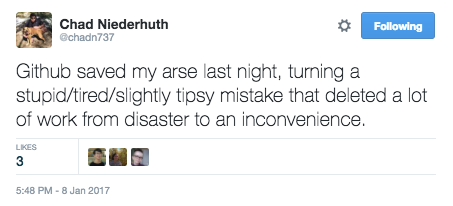

## Log in to GitHub

- Register for an account, if you don’t have one - then log in

[figure not shown]

## Create a remote repository

- Essentially, on GitHub’s servers:

```
mkdir planets
cd planets
git init
```

**Live Presentation**

## A freshly-made GitHub repository

- There’s nothing in the remote repository!

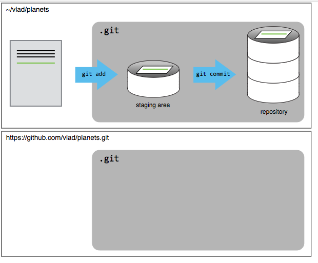

## Connecting local and remote repositories

- We tell the *local* repository that the GitHub repository is its *remote* repository.
  - `origin` is a local nickname for the remote repo (a common choice)
  - Once set up, we *push* changes/history to the remote repo

**Live Presentation**

```
git remote add origin https://github.com/widdowquinn/planets.git
git push origin master
```

## Remote GitHub repo after first *push*

- We only *push* the repository, not the staging area

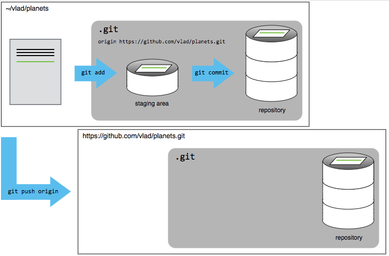

## My first remote *pull*

- To synchronise the local repo with the remote repo, we *pull*

**Live Presentation**

```
git pull origin master
```

## 9. GitHub collaboration

## Learning objectives

- Collaborate pushing changes to someone else’s remote repository

## Starting a collaboration

- Pair up as ‘owner’ and ‘collaborator’
- as *owner*: give GitHub repo access to your collaborator
- as *collaborator*: clone the *owner*’s repo

**Live Presentation**

```
cd /tmp/
git clone https://github.com/<collaborator>/planets.git
git remote -v
```

## Make a collaborative change

**as the *collaborator***

- Add a file called `pluto.txt` - (content your own)

**Live Presentation**

```
cd planets
nano pluto.txt
git add pluto.txt
git commit -m "Notes on Pluto"
git push origin master
```

## Pull a collaborator’s change

**as the *owner***

- Change back to your **own** repository
  - Check with `git remote -v`
- `git pull` the changes made by your collaborator

**Live Presentation**

```
cd ~/planets/
git pull origin master
```

## 10. Resolving `git` conflicts

## Learning objectives

- Understand what conflicts are, and when they occur
- To be able to resolve conflicts resulting from a merge

## Why conflicts occur

- People working in parallel
  - different changes to same part of a file
  - not keeping local repo in sync before making local changes
  - not keeping remote repo in sync after making local changes
- `git pull` before working; `git push` when done

## Seriously, `git push` when done…

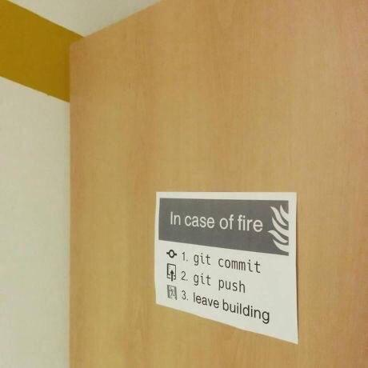

## Let’s make a conflict

**in your pairs**

- As the *owner*: add a line to `mars.txt`
  - Commit and push the change

**then**

- As the *collaborator*: add a line to `mars.txt`
  - Commit and push the change

**Live Presentation**

```
cd ~/planets
nano mars.txt
git push origin master
cd /tmp/planets
nano mars.txt
git push origin master
```

## The conflict message

```
To https://github.com/<collaborator>/planets.git
 ! [rejected]        master -> master (fetch first)
error: failed to push some refs to 'https://github.com/<collaborator>/planets.git'
hint: Updates were rejected because the remote contains work that you do
hint: not have locally. This is usually caused by another repository pushing
hint: to the same ref. You may want to first integrate the remote changes
hint: (e.g., 'git pull ...') before pushing again.
hint: See the 'Note about fast-forwards' in 'git push --help' for details.
```

## The conflicting changes

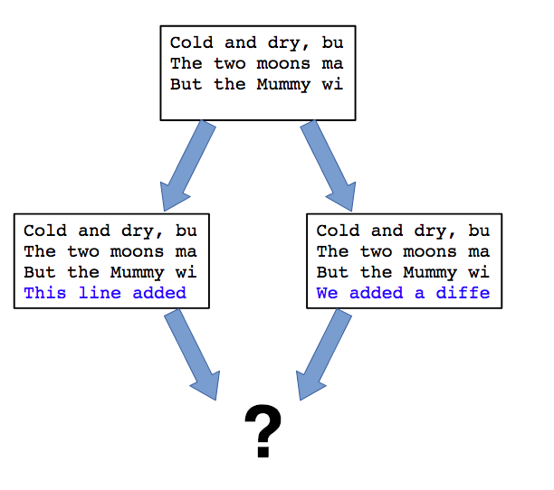

## Resolving a conflict

- `git` detects overlapping changes
  - `git` defers to humans for how to resolve: **communicate**!
- To resolve:
  - *pull* remote changes
  - *merge* changes into our working copy
  - *push* the merged changes

**Live Presentation**

## 11. Wrapping up

## Wrapping up

- GitHub/version control can be an open electronic lab book as part of Open Science workflows
  - Collect data - store in OA repository (Zenodo/FigShare)
  - Use GitHub to store work in progress: analysis lab book
  - Post preprint to (Bio)arXiv
- Even if you don’t work openly, it’s more reproducible (and auditable)

## You’re ready to leave this behind…

[figure not shown]